# Titanic P2

Kenda Maleh @ Uconnect Udacity intensive Introduction to Programming Nanodegree

A Data Analysis on Titanic Passenger Data

The following data analysis is done on 891 Titanic passenger data of demographic data on 891 and it shows how many did make it and survived and those who did not. The project answers questions of how many survived between using factors, age, gender and realted classes to reflect the factors that helped many of passenger to survive.

```python
import unicodecsv

with open('titanic-data.csv', 'rb') as f:
    reader = unicodecsv.DictReader(f)
    titanicdata= list(reader)


print titanicdata[0]
```

```
{u'Fare': u'7.25', u'Name': u'Braund, Mr. Owen Harris', u'Embarked': u'S', u'Age': u'22', u'Parch': u'0', u'Pclass': u'3', u'Sex': u'male', u'Survived': u'0', u'SibSp': u'1', u'PassengerId': u'1', u'Ticket': u'A/5 21171', u'Cabin': u''}
```

Checking data type

```python
print titatincdf.Survived.dtype
print titatincdf.Pclass.dtype
print titatincdf.Age.dtype
print titatincdf.SibSp.dtype
print titatincdf.Parch.dtype

Showing data types
```

[output not shown]

Clean age data from Nan using dropna which will make my sample is smaller

```python
import numpy as np
import pandas as pd


titatincdf = pd.read_csv('titanic-data.csv')



titatincdf.describe()
titatincdf = titatincdf.dropna()

titatincdf['Age']
titatincdf['Age']=titatincdf['Age'].apply(int)
print
#titatincdf =titatincdf['Age'].fillna(0)
titatincdf.describe()
```

|  | PassengerId | Survived | Pclass | Age | SibSp | Parch | Fare |
| --- | --- | --- | --- | --- | --- | --- | --- |
| count | 183.000000 | 183.000000 | 183.000000 | 183.000000 | 183.000000 | 183.000000 | 183.000000 |
| mean | 455.366120 | 0.672131 | 1.191257 | 35.661202 | 0.464481 | 0.475410 | 78.682469 |
| std | 247.052476 | 0.470725 | 0.515187 | 15.654054 | 0.644159 | 0.754617 | 76.347843 |
| min | 2.000000 | 0.000000 | 1.000000 | 0.000000 | 0.000000 | 0.000000 | 0.000000 |
| 25% | 263.500000 | 0.000000 | 1.000000 | 24.000000 | 0.000000 | 0.000000 | 29.700000 |
| 50% | 457.000000 | 1.000000 | 1.000000 | 36.000000 | 0.000000 | 0.000000 | 57.000000 |
| 75% | 676.000000 | 1.000000 | 1.000000 | 47.500000 | 1.000000 | 1.000000 | 90.000000 |
| max | 890.000000 | 1.000000 | 3.000000 | 80.000000 | 3.000000 | 4.000000 | 512.329200 |

I used describe to get staistical data from my data agains my passengers criterias.

```python
x=float(titatincdf.Sex[titatincdf.Survived== 1].count()) / float(titatincdf.Survived.count())
print x
```

```
0.672131147541
```

Overall survival ratio

```
Sex
female    88
male      95
Name: COUNTER, dtype: int64
```

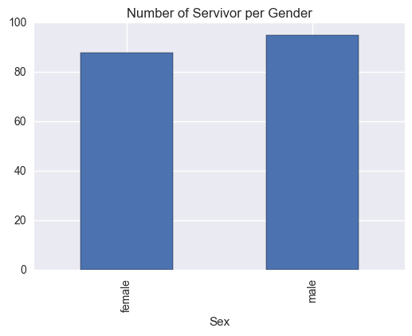

```python
# How many survived in each class
import pandas as pd
import matplotlib.pyplot as plt
titatincdf['COUNTER'] =1       #initially, set that counter to 1.
group_data = titatincdf.groupby(['Sex','Pclass']['Survived'==0])['COUNTER'].sum() #sum function
print(group_data)
%matplotlib inline
group_data.plot(kind='bar')

plt.title('Number of Servivor per Gender')
```

```python
mean of maximum fare ticket


x=titatincdf.values
def mean_riders_for_max_station(x):
    x=titatincdf.iloc[:,9:10]
    max_fare = x.max()
    mean_fare=  max_fare.mean()
    total_fare = x.mean();

    overall_mean = total_fare
    mean_for_max = mean_fare

    return (overall_mean, mean_for_max)
print mean_for_max_ticket(x)
```

[output not shown]

Calculating mean of column

```python
titatincdf.mean(axis=0)
```

[output not shown]

```python
titanic_data = titatincdf
titanic_data[(titanic_data['Age'] <=18) | (titanic_data.Sex =='female') & (titanic_data.Survived ==1)]
```

|  | PassengerId | Survived | Pclass | Name | Sex | Age | SibSp | Parch | Ticket | Fare | Cabin | Embarked |
| --- | --- | --- | --- | --- | --- | --- | --- | --- | --- | --- | --- | --- |
| 1 | 2 | 1 | 1 | Cumings, Mrs. John Bradley (Florence Briggs Th... | female | 38 | 1 | 0 | PC 17599 | 71.2833 | C85 | C |
| 3 | 4 | 1 | 1 | Futrelle, Mrs. Jacques Heath (Lily May Peel) | female | 35 | 1 | 0 | 113803 | 53.1000 | C123 | S |
| 10 | 11 | 1 | 3 | Sandstrom, Miss. Marguerite Rut | female | 4 | 1 | 1 | PP 9549 | 16.7000 | G6 | S |
| 11 | 12 | 1 | 1 | Bonnell, Miss. Elizabeth | female | 58 | 0 | 0 | 113783 | 26.5500 | C103 | S |
| 52 | 53 | 1 | 1 | Harper, Mrs. Henry Sleeper (Myna Haxtun) | female | 49 | 1 | 0 | PC 17572 | 76.7292 | D33 | C |
| 66 | 67 | 1 | 2 | Nye, Mrs. (Elizabeth Ramell) | female | 29 | 0 | 0 | C.A. 29395 | 10.5000 | F33 | S |
| 88 | 89 | 1 | 1 | Fortune, Miss. Mabel Helen | female | 23 | 3 | 2 | 19950 | 263.0000 | C23 C25 C27 | S |
| 123 | 124 | 1 | 2 | Webber, Miss. Susan | female | 32 | 0 | 0 | 27267 | 13.0000 | E101 | S |
| 136 | 137 | 1 | 1 | Newsom, Miss. Helen Monypeny | female | 19 | 0 | 2 | 11752 | 26.2833 | D47 | S |
| 151 | 152 | 1 | 1 | Pears, Mrs. Thomas (Edith Wearne) | female | 22 | 1 | 0 | 113776 | 66.6000 | C2 | S |
| 183 | 184 | 1 | 2 | Becker, Master. Richard F | male | 1 | 2 | 1 | 230136 | 39.0000 | F4 | S |
| 193 | 194 | 1 | 2 | Navratil, Master. Michel M | male | 3 | 1 | 1 | 230080 | 26.0000 | F2 | S |
| 194 | 195 | 1 | 1 | Brown, Mrs. James Joseph (Margaret Tobin) | female | 44 | 0 | 0 | PC 17610 | 27.7208 | B4 | C |
| 195 | 196 | 1 | 1 | Lurette, Miss. Elise | female | 58 | 0 | 0 | PC 17569 | 146.5208 | B80 | C |
| 205 | 206 | 0 | 3 | Strom, Miss. Telma Matilda | female | 2 | 0 | 1 | 347054 | 10.4625 | G6 | S |
| 215 | 216 | 1 | 1 | Newell, Miss. Madeleine | female | 31 | 1 | 0 | 35273 | 113.2750 | D36 | C |
| 218 | 219 | 1 | 1 | Bazzani, Miss. Albina | female | 32 | 0 | 0 | 11813 | 76.2917 | D15 | C |
| 230 | 231 | 1 | 1 | Harris, Mrs. Henry Birkhardt (Irene Wallach) | female | 35 | 1 | 0 | 36973 | 83.4750 | C83 | S |
| 257 | 258 | 1 | 1 | Cherry, Miss. Gladys | female | 30 | 0 | 0 | 110152 | 86.5000 | B77 | S |
| 268 | 269 | 1 | 1 | Graham, Mrs. William Thompson (Edith Junkins) | female | 58 | 0 | 1 | PC 17582 | 153.4625 | C125 | S |
| 269 | 270 | 1 | 1 | Bissette, Miss. Amelia | female | 35 | 0 | 0 | PC 17760 | 135.6333 | C99 | S |
| 275 | 276 | 1 | 1 | Andrews, Miss. Kornelia Theodosia | female | 63 | 1 | 0 | 13502 | 77.9583 | D7 | S |
| 291 | 292 | 1 | 1 | Bishop, Mrs. Dickinson H (Helen Walton) | female | 19 | 1 | 0 | 11967 | 91.0792 | B49 | C |
| 297 | 298 | 0 | 1 | Allison, Miss. Helen Loraine | female | 2 | 1 | 2 | 113781 | 151.5500 | C22 C26 | S |
| 299 | 300 | 1 | 1 | Baxter, Mrs. James (Helene DeLaudeniere Chaput) | female | 50 | 0 | 1 | PC 17558 | 247.5208 | B58 B60 | C |
| 305 | 306 | 1 | 1 | Allison, Master. Hudson Trevor | male | 0 | 1 | 2 | 113781 | 151.5500 | C22 C26 | S |
| 307 | 308 | 1 | 1 | Penasco y Castellana, Mrs. Victor de Satode (M... | female | 17 | 1 | 0 | PC 17758 | 108.9000 | C65 | C |
| 309 | 310 | 1 | 1 | Francatelli, Miss. Laura Mabel | female | 30 | 0 | 0 | PC 17485 | 56.9292 | E36 | C |
| 310 | 311 | 1 | 1 | Hays, Miss. Margaret Bechstein | female | 24 | 0 | 0 | 11767 | 83.1583 | C54 | C |
| 311 | 312 | 1 | 1 | Ryerson, Miss. Emily Borie | female | 18 | 2 | 2 | PC 17608 | 262.3750 | B57 B59 B63 B66 | C |
| ... | ... | ... | ... | ... | ... | ... | ... | ... | ... | ... | ... | ... |
| 585 | 586 | 1 | 1 | Taussig, Miss. Ruth | female | 18 | 0 | 2 | 110413 | 79.6500 | E68 | S |
| 591 | 592 | 1 | 1 | Stephenson, Mrs. Walter Bertram (Martha Eustis) | female | 52 | 1 | 0 | 36947 | 78.2667 | D20 | C |
| 609 | 610 | 1 | 1 | Shutes, Miss. Elizabeth W | female | 40 | 0 | 0 | PC 17582 | 153.4625 | C125 | S |
| 618 | 619 | 1 | 2 | Becker, Miss. Marion Louise | female | 4 | 2 | 1 | 230136 | 39.0000 | F4 | S |
| 627 | 628 | 1 | 1 | Longley, Miss. Gretchen Fiske | female | 21 | 0 | 0 | 13502 | 77.9583 | D9 | S |
| 641 | 642 | 1 | 1 | Sagesser, Mlle. Emma | female | 24 | 0 | 0 | PC 17477 | 69.3000 | B35 | C |
| 689 | 690 | 1 | 1 | Madill, Miss. Georgette Alexandra | female | 15 | 0 | 1 | 24160 | 211.3375 | B5 | S |
| 700 | 701 | 1 | 1 | Astor, Mrs. John Jacob (Madeleine Talmadge Force) | female | 18 | 1 | 0 | PC 17757 | 227.5250 | C62 C64 | C |
| 710 | 711 | 1 | 1 | Mayne, Mlle. Berthe Antonine ("Mrs de Villiers") | female | 24 | 0 | 0 | PC 17482 | 49.5042 | C90 | C |
| 716 | 717 | 1 | 1 | Endres, Miss. Caroline Louise | female | 38 | 0 | 0 | PC 17757 | 227.5250 | C45 | C |
| 717 | 718 | 1 | 2 | Troutt, Miss. Edwina Celia "Winnie" | female | 27 | 0 | 0 | 34218 | 10.5000 | E101 | S |
| 730 | 731 | 1 | 1 | Allen, Miss. Elisabeth Walton | female | 29 | 0 | 0 | 24160 | 211.3375 | B5 | S |
| 742 | 743 | 1 | 1 | Ryerson, Miss. Susan Parker "Suzette" | female | 21 | 2 | 2 | PC 17608 | 262.3750 | B57 B59 B63 B66 | C |
| 751 | 752 | 1 | 3 | Moor, Master. Meier | male | 6 | 0 | 1 | 392096 | 12.4750 | E121 | S |
| 759 | 760 | 1 | 1 | Rothes, the Countess. of (Lucy Noel Martha Dye... | female | 33 | 0 | 0 | 110152 | 86.5000 | B77 | S |
| 763 | 764 | 1 | 1 | Carter, Mrs. William Ernest (Lucile Polk) | female | 36 | 1 | 2 | 113760 | 120.0000 | B96 B98 | S |
| 765 | 766 | 1 | 1 | Hogeboom, Mrs. John C (Anna Andrews) | female | 51 | 1 | 0 | 13502 | 77.9583 | D11 | S |
| 779 | 780 | 1 | 1 | Robert, Mrs. Edward Scott (Elisabeth Walton Mc... | female | 43 | 0 | 1 | 24160 | 211.3375 | B3 | S |
| 781 | 782 | 1 | 1 | Dick, Mrs. Albert Adrian (Vera Gillespie) | female | 17 | 1 | 0 | 17474 | 57.0000 | B20 | S |
| 796 | 797 | 1 | 1 | Leader, Dr. Alice (Farnham) | female | 49 | 0 | 0 | 17465 | 25.9292 | D17 | S |
| 802 | 803 | 1 | 1 | Carter, Master. William Thornton II | male | 11 | 1 | 2 | 113760 | 120.0000 | B96 B98 | S |
| 809 | 810 | 1 | 1 | Chambers, Mrs. Norman Campbell (Bertha Griggs) | female | 33 | 1 | 0 | 113806 | 53.1000 | E8 | S |
| 820 | 821 | 1 | 1 | Hays, Mrs. Charles Melville (Clara Jennings Gr... | female | 52 | 1 | 1 | 12749 | 93.5000 | B69 | S |
| 823 | 824 | 1 | 3 | Moor, Mrs. (Beila) | female | 27 | 0 | 1 | 392096 | 12.4750 | E121 | S |
| 835 | 836 | 1 | 1 | Compton, Miss. Sara Rebecca | female | 39 | 1 | 1 | PC 17756 | 83.1583 | E49 | C |
| 853 | 854 | 1 | 1 | Lines, Miss. Mary Conover | female | 16 | 0 | 1 | PC 17592 | 39.4000 | D28 | S |
| 862 | 863 | 1 | 1 | Swift, Mrs. Frederick Joel (Margaret Welles Ba... | female | 48 | 0 | 0 | 17466 | 25.9292 | D17 | S |
| 871 | 872 | 1 | 1 | Beckwith, Mrs. Richard Leonard (Sallie Monypeny) | female | 47 | 1 | 1 | 11751 | 52.5542 | D35 | S |
| 879 | 880 | 1 | 1 | Potter, Mrs. Thomas Jr (Lily Alexenia Wilson) | female | 56 | 0 | 1 | 11767 | 83.1583 | C50 | C |
| 887 | 888 | 1 | 1 | Graham, Miss. Margaret Edith | female | 19 | 0 | 0 | 112053 | 30.0000 | B42 | S |

91 rows × 12 columns